# Prosper loans dataset Investigation

## by David Anifowoshe

## Investigation Overview

> In this presentation. Many visualizations on loans's characterics will be created to answer two main questions:
> - What are the variables that can be employed to predict credit default?
> - What are the elements that have impact on Prosper's rating?

## Dataset Overview

> In this dataset we have data about Prosper, a credit company that facilitates peer-to-peer lending. There are 113,937 loans in total, with 81 different variables. I used the following factors to conduct my investigation: Term, LoanStatus, BorrowerRate, ProsperRating (Alpha), ListingCategory (numeric), EmploymentStatus, DelinquenciesLast7Years, StatedMonthlyIncome, TotalProsperLoans, LoanOriginalAmount, LoanOriginationDate, Recommendations, and Investors are some of the terms used by Prosper.

## Wrangling

We have three key data issues:

1. Since 2009, Prosper has been using the Prosper grading system. Credit Grade was used by Prosper before to 2009. Pre-2009 data points had to be completely removed.
2. The majority of the loans in the dataset are current loans, hence they cannot be used to predict credit default. Chargedoff and defaulted credits were the two types of defaulted credits (see sub-slide).To fix this, I deleted all existing loans and combined chargedoff and defaulted credits.
3. The number of outliers in stated monthly income was exceptionally high, with a wide range of numbers from 0 to 1750000. To remedy this, I removed all data that was more than three standard deviations away from the mean.

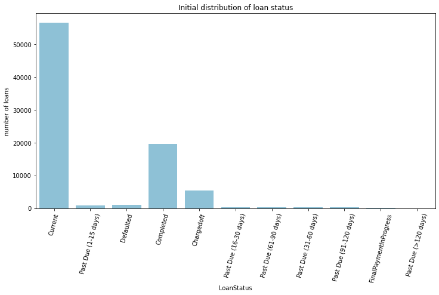

Now there are 26005 loans in the data set after wrangling: 19664 Completed loans and 6341 Defaulted loans.

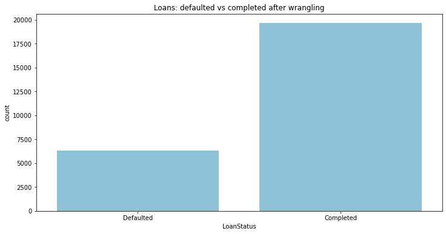

The Monthly Income Distribution looks to be about normal after some wrangling, with a high right skew and a mean of `$5328` and a maximum value of `$30416`.

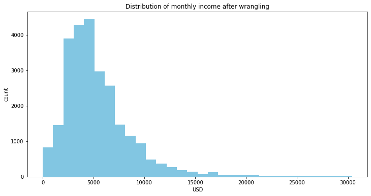

ProsperRating is an ordinal categorical variable with the values ('AA', 'A', 'B', 'C', 'D', 'E', 'HR') from higher to lower.

In the data set, ratings have a nearly normal distribution, with the highest 'AA' and lowest 'HR' ratings having the fewest occurrences.

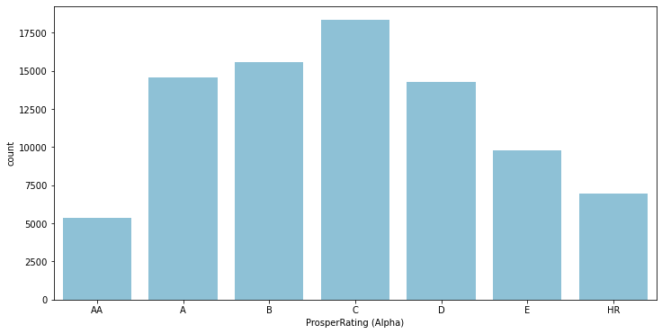

The lower Prosper rating, the more defaults on credits, With the exception of rating D, which turns out to be the most prevalent rating among defaulted credits.

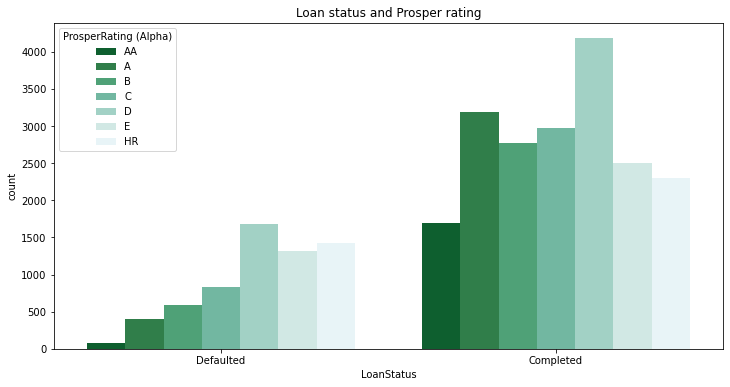

Individuals with employment status 'Not employed' or 'Self-employed' are more prone to default on credit:

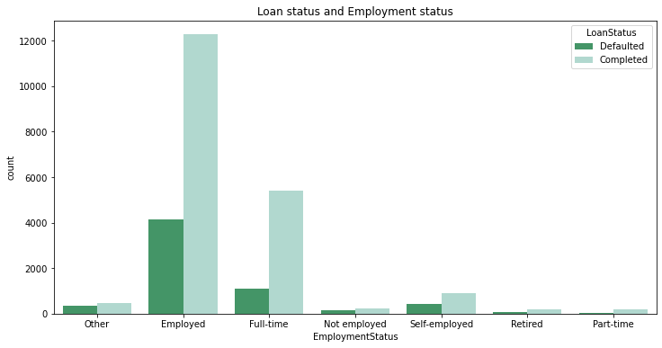

Long-term (60-month) credit has the highest percentage of defaulted credits.

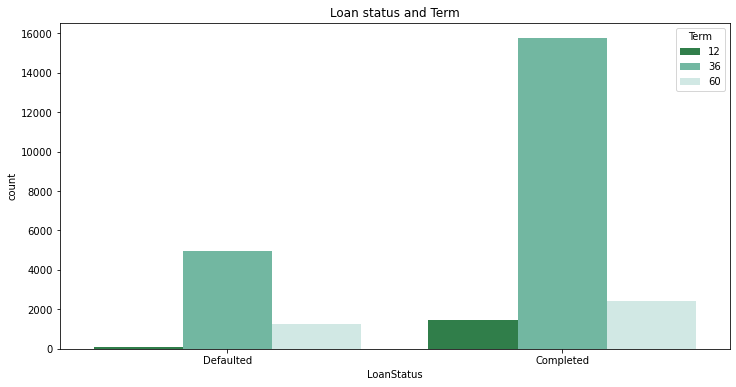

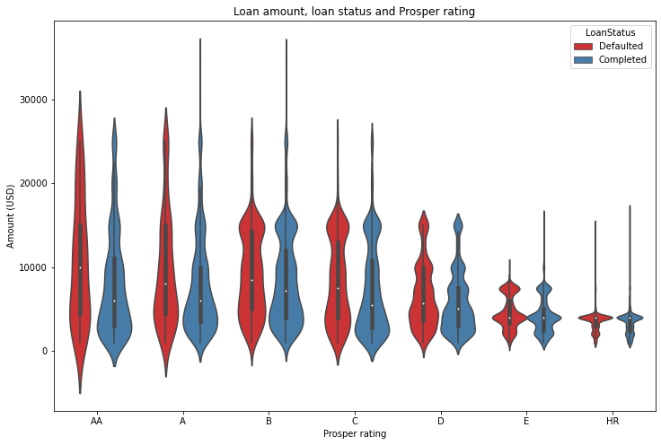

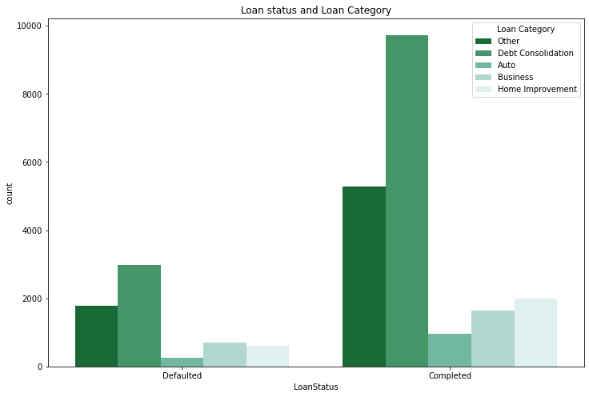

Individuals with high rating tend to have higher monthly income.

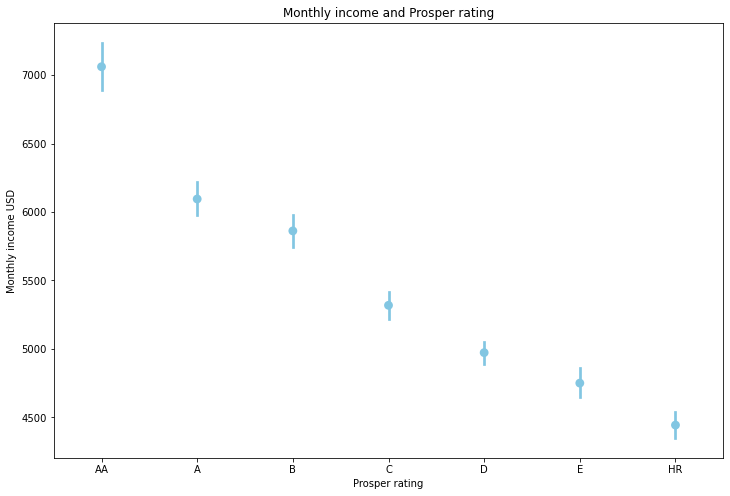

The proportion of people with the employment classifications 'Not employed,' 'Self-employed,' and 'Retired' rises as the Prosper rating falls.

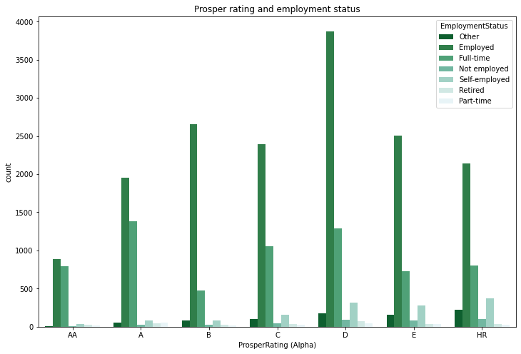